# Redo _explain slides

### Analysis of Nutritional Supplements & Visualization of Selected Cereals

### Research Questions

- 1. What Products are rich in Carbohydrate, Protein, Vitamin & Mineral
- 1. Find products not suitbale for diabetic patients (above 60g)
- 1. Find products suitbale for diabetic patients (equal or below 60g)
- 1. Cereals with highest rating

### Assessment

> Information of the dataset

```python
food.info()
```

```
<class 'pandas.core.frame.DataFrame'>
RangeIndex: 77 entries, 0 to 76
Data columns (total 16 columns):
 #   Column    Non-Null Count  Dtype
---  ------    --------------  -----
 0   name      77 non-null     object
 1   mfr       77 non-null     object
 2   type      77 non-null     object
 3   calories  77 non-null     int64
 4   protein   77 non-null     int64
 5   fat       77 non-null     int64
 6   sodium    77 non-null     int64
 7   fiber     77 non-null     float64
 8   carbo     77 non-null     float64
 9   sugars    77 non-null     int64
 10  potass    77 non-null     int64
 11  vitamins  77 non-null     int64
 12  shelf     77 non-null     int64
 13  weight    77 non-null     float64
 14  cups      77 non-null     float64
 15  rating    77 non-null     float64
dtypes: float64(5), int64(8), object(3)
memory usage: 9.8+ KB
```

> Genreally there our data is clean

> There are no null values and each feature have the correct datatypes

#### Research Question 1

1. What Products are rich in Carbohydrate, Protein, Vitamin & Mineral

> Crabohydrate Foods

> Define

> > Group food types that are of carbohydrate and plot distribution of top 5 and lowest 5

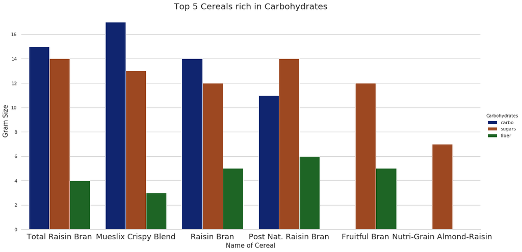

```python
sns.set(style="whitegrid")
plot = sns.catplot(x='name', y='grams',hue = 'Carbohydrates',  data=top5_carbo,
           aspect=2, kind='bar', height=8, palette=["#001C7F", "#B1400D", '#12711C'])

plt.title('Top 5 Cereals rich in Carbohydrates', fontsize=20)
plt.xticks(rotation=0, fontsize=18)
plt.xlabel('Name of Cereal', fontsize=15)
plt.ylabel('Gram Size', fontsize=15)
plot.despine(left=True)
plt.savefig(format='png', fname='visuals2/top_carbo.png')
plt.show()
```

#### Lowest 5 Carbohydrate Foods

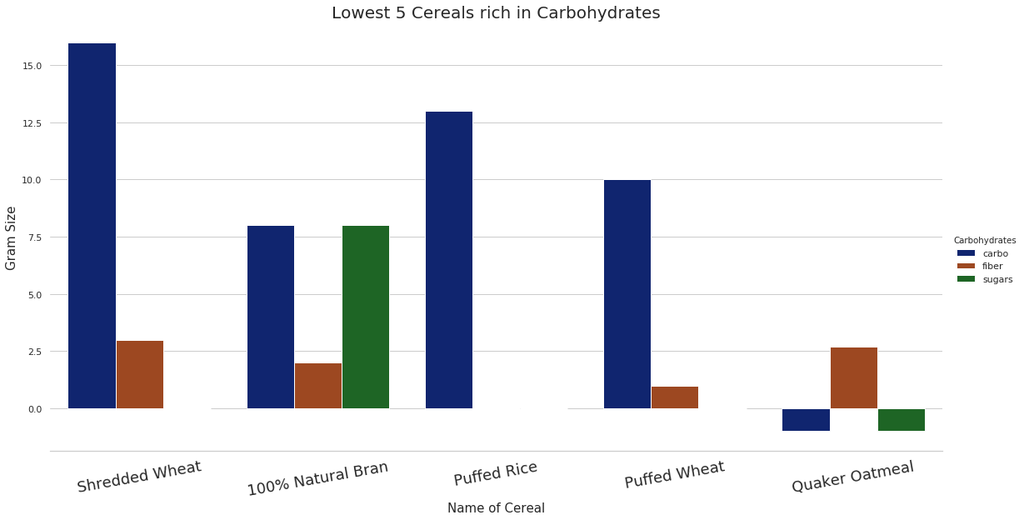

```python
sns.set(style="whitegrid")
plot = sns.catplot(x='name', y='grams',hue = 'Carbohydrates',  data=low5_carbo,
           aspect=2, kind='bar', height=8, palette=["#001C7F", "#B1400D", '#12711C'])

plt.title('Lowest 5 Cereals rich in Carbohydrates', fontsize=20)
plt.xticks(rotation=10, fontsize=18)
plt.xlabel('Name of Cereal', fontsize=15)
plt.ylabel('Gram Size', fontsize=15)
plot.despine(left=True)
plt.savefig(format='png', fname='visuals2/low_carbo.png')
plt.show()
```

> Protein Foods

> Define

> > Group food types that are of protein and plot distribution of top 5 and lowest 5

```python
top5_protein
```

|  | name | protein |
| --- | --- | --- |
| 0 | Cheerios | 6 |
| 1 | Special K | 6 |
| 2 | Quaker Oatmeal | 5 |
| 3 | 100% Bran | 4 |
| 4 | All-Bran | 4 |

#### Top 5 Cereals rich in Protein

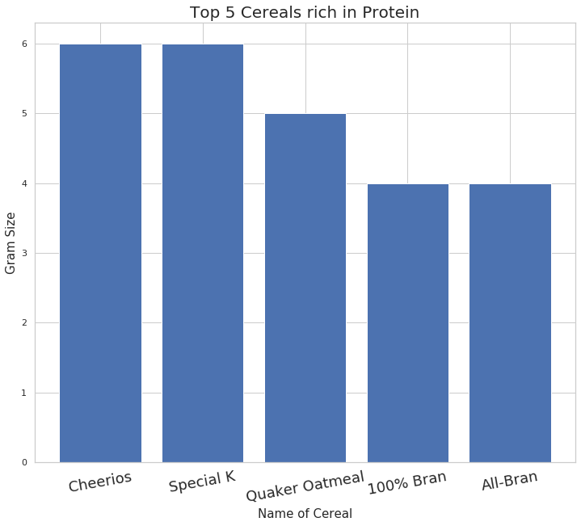

```python
plt.subplots(figsize=(12, 10))
plt.bar(x=top5_protein.name, height=top5_protein.protein)
plt.title("Top 5 Cereals rich in Protein", fontsize=20)
plt.xticks(rotation=10, fontsize=18)
plt.xlabel('Name of Cereal', fontsize=15)
plt.ylabel('Gram Size', fontsize=15)
plot.despine(left=True)
plt.savefig(format='png', fname='visuals2/top_protein.png')
plt.show()
```

```python
low_protein = low5_protein.query('protein < 2.5' ).name
lowest_protein = pd.DataFrame(low5_protein)
low_protein
```

```
39                      Bran Chex
40                    Apple Jacks
41        Apple Cinnamon Cheerios
42                        Crispix
43                 Almond Delight
44         Crispy Wheat & Raisins
45                    Corn Flakes
46                      Corn Chex
47                    Double Chex
48                    Froot Loops
49            Wheaties Honey Gold
50    Just Right Crunchy  Nuggets
51                 Raisin Squares
52                   Golden Crisp
53                        Triples
```

[output cut: 24 more lines]

> Vitamin Foods

> Define

> > Foods that have are rich or lack in vitamins

```python
no_vitmain_foods
```

|  | name | vitamins |
| --- | --- | --- |
| 1 | 100% Natural Bran | 0 |
| 20 | Cream of Wheat (Quick) | 0 |
| 54 | Puffed Rice | 0 |
| 55 | Puffed Wheat | 0 |
| 57 | Quaker Oatmeal | 0 |
| 63 | Shredded Wheat | 0 |
| 64 | Shredded Wheat 'n'Bran | 0 |
| 65 | Shredded Wheat spoon size | 0 |

```python
rich_vitmain_foods
```

|  | name | vitamins |
| --- | --- | --- |
| 38 | Just Right Crunchy Nuggets | 100 |
| 39 | Just Right Fruit & Nut | 100 |
| 53 | Product 19 | 100 |
| 69 | Total Corn Flakes | 100 |
| 70 | Total Raisin Bran | 100 |
| 71 | Total Whole Grain | 100 |

> Mineral Foods

> Define

> > Top 5 Cereals and LOwest 5 Cereals rich in Minerals

#### Top 5 Cereals rich in Minerals

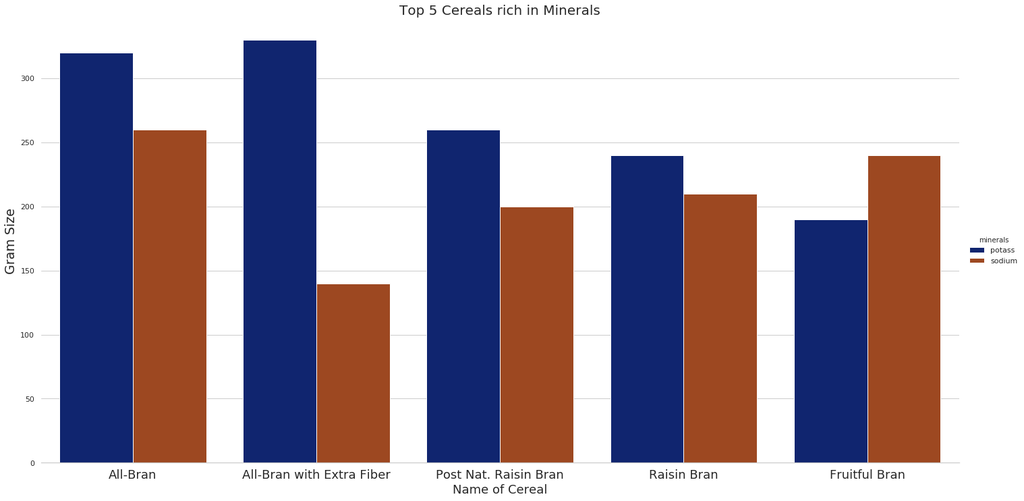

```python
sns.set(style="whitegrid")
plot = sns.catplot(x='name', y='grams',hue = 'minerals',  data=top5_minerals,
           aspect=2, kind='bar', height=10, palette=["#001C7F", "#B1400D"])

plt.title('Top 5 Cereals rich in Minerals', fontsize=20)
plt.xticks(rotation=0, fontsize=18)
plt.xlabel('Name of Cereal', fontsize=18)
plt.ylabel('Gram Size', fontsize=19)
plot.despine(left=True)
plt.savefig(format='png', fname='visuals2/top_minerals.png')
plt.show()
```

> Lowest 5 Minerals Cereals

#### Lowest 5 Cereals rich in Minerals

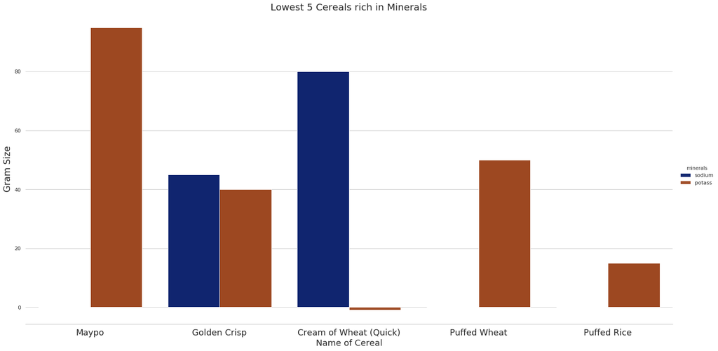

```python
sns.set(style="whitegrid")
plot = sns.catplot(x='name', y='grams',hue = 'minerals',  data=low5_minerals,
           aspect=2, kind='bar', height=10, palette=["#001C7F", "#B1400D"])

plt.title('Lowest 5 Cereals rich in Minerals', fontsize=20)
plt.xticks(rotation=0, fontsize=18)
plt.xlabel('Name of Cereal', fontsize=18)
plt.ylabel('Gram Size', fontsize=19)
plot.despine(left=True)
plt.savefig(format='png', fname='visuals2/low_minerals.png')
plt.show()
```

### Research Question 2 & 3

- Find products not suitbale for diabetic patients (above 60g)
- Find products suitbale for diabetic patients (equal or below 60g)

```python
diabetic_foods
```

|  | name | Carbohydrates | sum | grams |
| --- | --- | --- | --- | --- |

### Observation

#### Are there products not suitable for diabetic patients (greater than 60g)

> After filtering our data, we discivered there are no cereals that are unsuitbale to diabetic patients

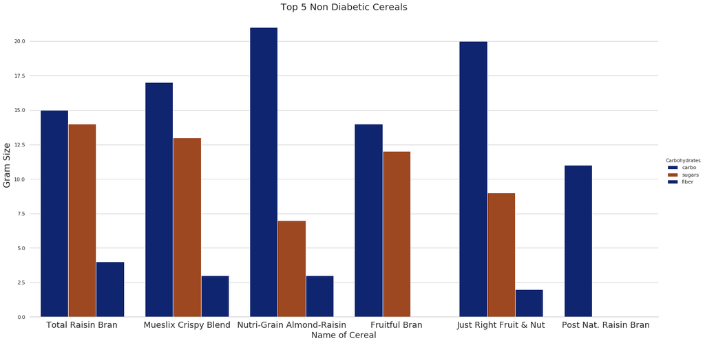

```python
sns.set(style="whitegrid")
plot = sns.catplot(x='name', y='grams',hue = 'Carbohydrates',  data=top_non_diabetic_foods,
           aspect=2, kind='bar', height=10, palette=["#001C7F", "#B1400D"])

plt.title('Top 5 Non Diabetic Cereals', fontsize=20)
plt.xticks(rotation=0, fontsize=18)
plt.xlabel('Name of Cereal', fontsize=18)
plt.ylabel('Gram Size', fontsize=19)
plot.despine(left=True)
plt.savefig(format='png', fname='visuals2/top_non_diabetic.png')
plt.show()
```

### Research Question 4

- Cereals with Highest Rating

#### What Cereals have the highest consumer ratings ?

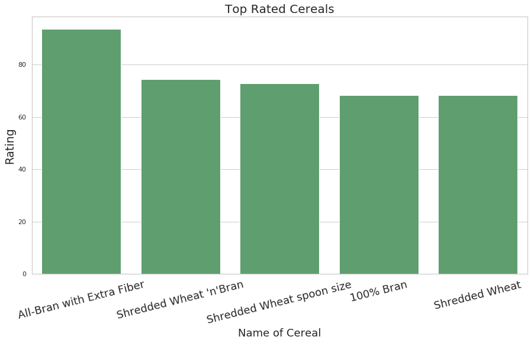

```python
# plt.subplot(figsize=(6.5))
fig_dims = (15, 8)
fig, ax = plt.subplots(figsize=fig_dims)
sns.set(style="whitegrid")
sns.barplot(x='name', y='rating', data=top_rated_food, ax =ax, color='g')
plt.title('Top Rated Cereals', fontsize=20)
plt.xticks(rotation=14, fontsize=18)
plt.xlabel('Name of Cereal', fontsize=18)
plt.ylabel('Rating', fontsize=19)
plot.despine(left=True)
plt.savefig(format='png', fname='visuals2/top_rated.png')
plt.show()
```

#### Low Rated Cereals

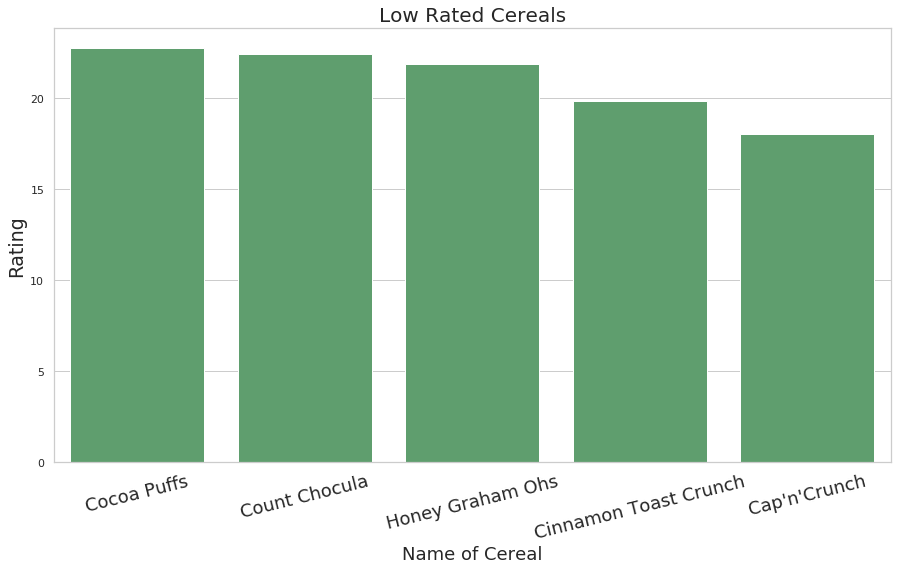

```python
# plt.subplot(figsize=(6.5))
fig_dims = (15, 8)
fig, ax = plt.subplots(figsize=fig_dims)
sns.set(style="whitegrid")
sns.barplot(x='name', y='rating', data=low_rated_food, ax =ax, color='g')
plt.title('Low Rated Cereals', fontsize=20)
plt.xticks(rotation=14, fontsize=18)
plt.xlabel('Name of Cereal', fontsize=18)
plt.ylabel('Rating', fontsize=19)
plot.despine(left=True)
plt.savefig(format='png', fname='visuals2/low_rated.png')
plt.show()
```

### Conclusions & Recommnedations

> It was discovered that `100%` Bran which has one of the highest ratings, are recomneded has good cereals

### Limitaions

> We believe with more data we can make more inferences

#### References

['https://www.cdc.gov/diabetes/managing/eat-well/diabetes-and-carbohydrates.html']